# Social Change in Future Selves:

A Portrait of Youths’ Views of Themselves in Adult Caring Roles

Joanna R. Pepin

*University of Toronto*

Melissa A. Milkie

*University of Toronto*

# Background

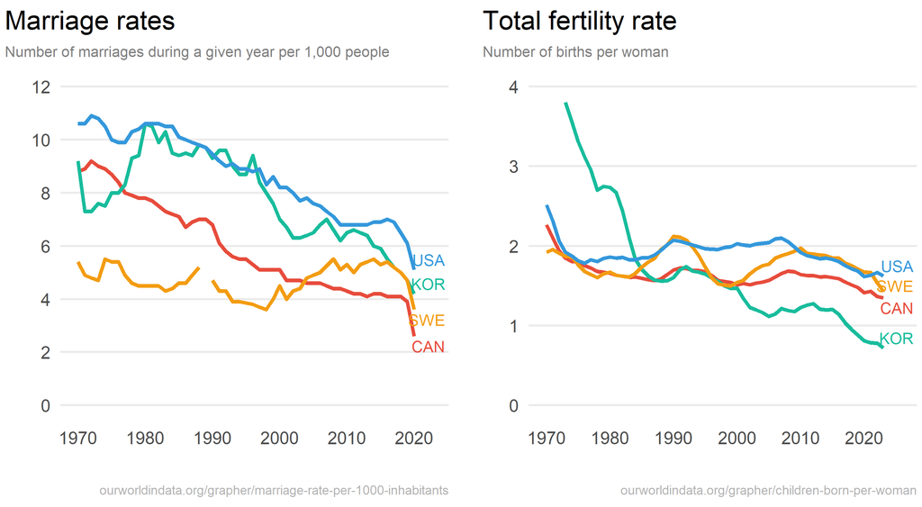

## Caregiving Ambitions Framework

[Bear 2019](https://journals.aom.org/doi/10.5465/amr.2016.0424)

**Motivation to give care**, across a variety of contexts and over the lifespan, **is central to understanding life goals** and ultimately behavior

## Expand definition of

## caregiving:

- Caring for a spouse
- In-direct care

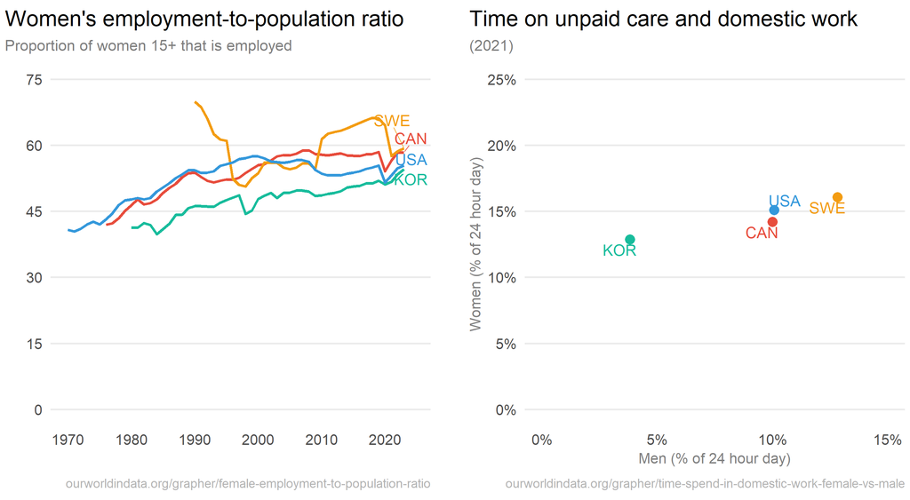

## Research Questions

1. Are there **changes** in youths’ views of their future selves as spouses, parents, and workers?
2. Do these projected future selves vary by **gender**?

# Monitoring the Future Surveys (1976-2023)

*Nationally representative sample of U.S. 12th-graders*  
N = 99,399

https://www.icpsr.umich.edu/web/ICPSR/series/35

These next questions ask you to guess how well you might do in several different situations. **How good do you think you would be as a**:

- **husband or wife?**
- **parent?**
- **worker on a job?**

**Response options**:

1. poor
2. not so good
3. fairly good
4. good
5. very good

## Key IVs

- Year
- Year<sup>2</sup>
- Gender

[figure not shown]

## Sample

[output not shown]

# Findings

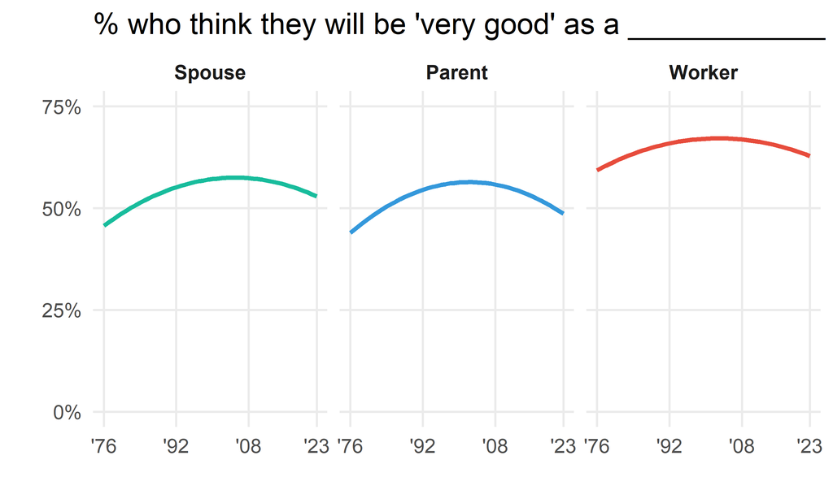

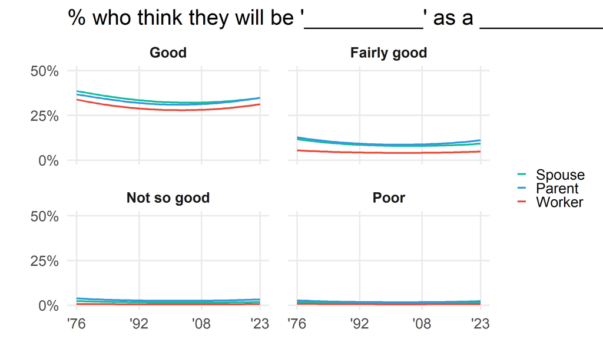

Predicted % from ordinal logistic regression with year + year<sup>2</sup>

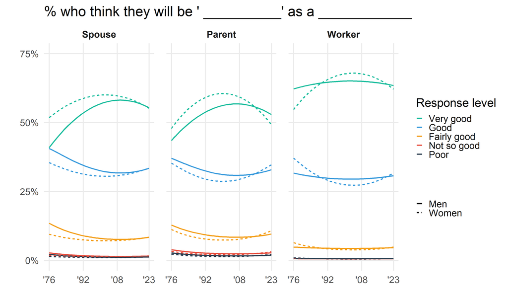

Predicted % from ordinal logistic regression with year, year<sup>2</sup>, gender, mom’s edu., race, & region

# Expectations

# Mom’s Education

# Next Steps

- Link with actual marriage/parenthood transitions

# Thank you!

Joanna R. Pepin  
*University of Toronto*

Melissa A. Milkie  
*University of Toronto*

[figure not shown]